# [Pseudocódigo](https://en.wikipedia.org/wiki/Pseudocode)

Es un lenguaje de descripción de algoritmos pensado como borrador: no lo ejecuta la computadora, pero sirve para diseñar la lógica antes de traducirla a un lenguaje de programación concreto.

- **Ventajas principales**
  1. **Enfoque en la lógica y el control** sin detalles sintácticos del lenguaje de destino.
  2. **Facilidad de modificación** al detectar errores conceptuales antes de codificar.
  3. **Portabilidad lógica** hacia lenguajes estructurados.
- **Características**
  - Palabras clave en inglés similares a las de los lenguajes reales: `start`, `end`, `if-then-else`, `while-end`, `repeat-until`, etc.
  - **Indentación** para reflejar la jerarquía de instrucciones.
  - Una acción por línea.

## Ejemplo

**Problema**: *obtener la suma de todos los numeros pares entre el 2 y el 100.*

**Pseudocódigo**:

```
pseudocode
ENTERO numero, suma
suma    ← 2
numero  ← 4
MIENTRAS (numero ≤ 100) HACER
    suma   ← suma + numero
    numero ← numero + 2
FIN MIENTRAS
ESCRIBE ('Suma pares entre 2 y 100 =', suma)
```

# [Diagramas de flujo](https://en.wikipedia.org/wiki/Flowchart)

Son representaciones gráficas de algoritmos en las que los pasos se colocan dentro de símbolos normalizados (cajas) y se enlazan con flechas que marcan la secuencia de ejecución.

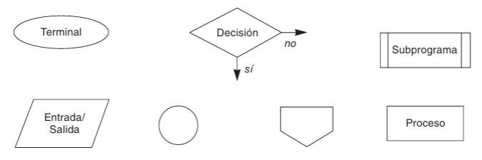

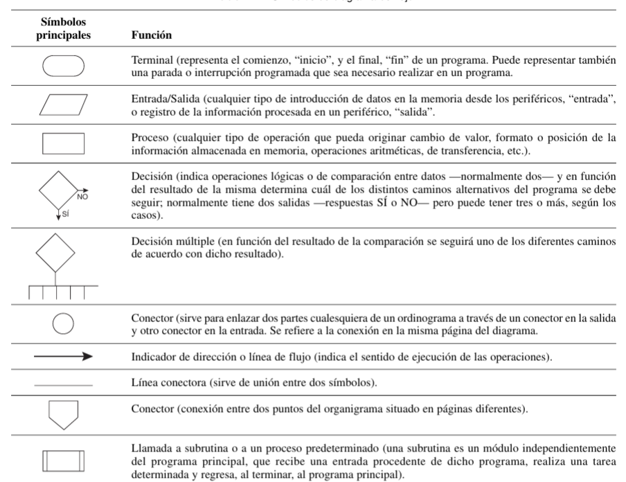

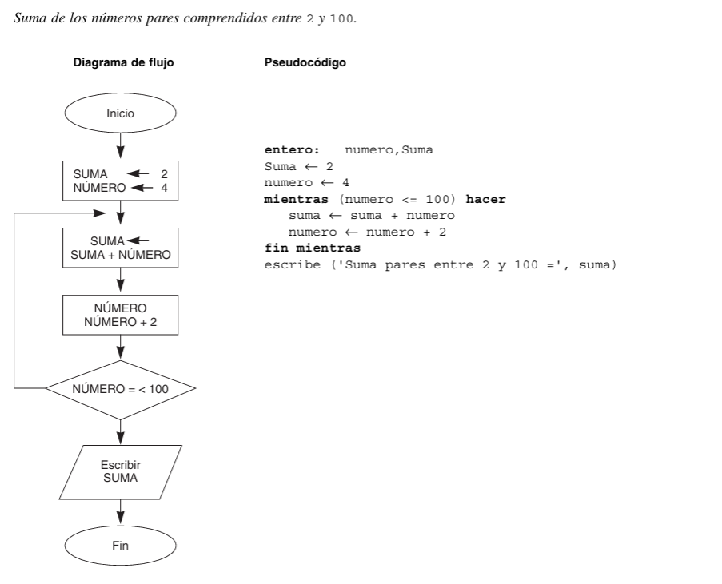

# [Paradigmas de programación](https://es.wikipedia.org/wiki/Paradigma_de_programaci%C3%B3n)

Python fue diseñado deliberadamente como lenguaje multiparadigma:

[output not shown]

# [Programación estructurada](https://es.wikipedia.org/wiki/Programaci%C3%B3n_estructurada)

La programación estructurada es un paradigma que prescribe organizar el flujo de control de un programa únicamente mediante tres construcciones básicas [(Teorema del programa estructurado,Böhm-Jacopini, 1966)](https://es.wikipedia.org/wiki/Teorema_del_programa_estructurado):

1. **Secuencia** – instrucciones que se ejecutan una tras otra.
2. **Selección** – bifurcaciones controladas ( `if / else` ).
3. **Iteración** – bucles con prueba explícita ( `for, while` ).

Se evita el uso indiscriminado de saltos incondicionales (`goto`) porque dificultan el seguimiento lógico del código. Las ventajas principales son:

- **Legibilidad** – la lógica completa puede seguirse de arriba hacia abajo.
- **Verificabilidad** – es más sencillo razonar formalmente sobre la corrección.
- **Mantenibilidad** – los cambios se localizan en bloques bien delimitados.

# Bibliografía

1. [“Go To Statement Considered Harmful” de E. W. Dijkstra (Communications of the ACM, marzo de 1968)](https://homepages.cwi.nl/~storm/teaching/reader/Dijkstra68.pdf)
2. [Ejemplo de sentencia goto documentado como válido para manejo de errores y liberación de recursos](https://www.geeksforgeeks.org/c/using-goto-for-exception-handling-in-c/)
3. Luis Joyanes Aguilar. (2008). Fundamentos de Programacion. Madrid: MC CREW HILL.